# HW3_KinjalRay

Kinjal

10/17/2018

```r
citibike <- read.csv("citibike.csv")
View(citibike)
```

## Q1

Males, on average, have shorter durations. Males, on average, travel longer distances.

```r
tapply(citibike$tripduration, citibike$gender, mean, na.rm = TRUE)[-1]
```

```
##        1        2
## 624.6843 713.5721
```

```r
library("geosphere")
citibike$distance = distHaversine(citibike[ ,c("start.station.longitude", "start.station.latitude")],citibike[ ,c("end.station.longitude", "end.station.latitude")])

tapply(citibike$distance, citibike$gender, mean, na.rm = TRUE)[-1]
```

```
##        1        2
## 1427.471 1409.683
```

```r
citibike$weekday <- factor(weekdays(as.Date(citibike$starttime, format = "%m/%d/%Y")), levels = c("Sunday","Monday","Tuesday","Wednesday","Thursday","Friday","Saturday"))
```

```r
as.POSIXlt(citibike$starttime, format = "%m/%d/%Y %H:%M")

citibike$hourtime <- format(as.POSIXct(strptime(citibike$starttime,"%d/%m/%Y %H:%M",tz="")) ,format = "%H")

citibike$hourtime <- as.integer(citibike$hourtime)
#citibike$hourtime[is.na(citibike$hourtime)] <- 30
unique(citibike$hourtime)
```

[output not shown]

## Q2

On weekdays, most traffic occurs, in the 7:30 AM - 10:00 AM and 3:00 PM - 6:00 PM ranges. On weekends, traffic is pretty consistent throughout the day, from 7:30 AM to 5:30 PM.

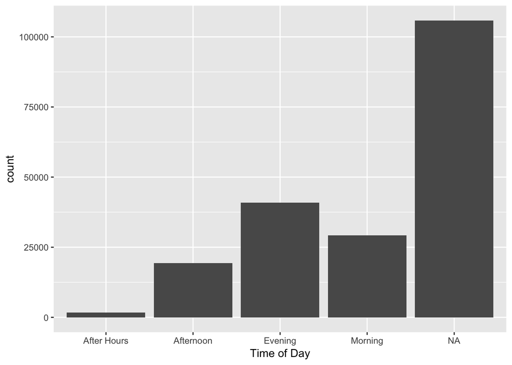

```r
citibike$weekend <- ifelse(citibike$weekday == "Monday" | citibike$weekday == "Tuesday" |citibike$weekday == "Wednesday" |citibike$weekday == "Thursday" |citibike$weekday == "Friday", "Weekday", "Weekend")

citibike$timeOfDay <- ifelse(citibike$hourtime >= 04 & citibike$hourtime < 12, "Morning",ifelse(citibike$hourtime >= 12 & citibike$hourtime < 16, "Afternoon", ifelse(citibike$hourtime >= 16 & citibike$hourtime < 24, "Evening", "After Hours")))

library(ggplot2)

ggplot(citibike, aes(citibike$timeOfDay)) + geom_bar() + labs(x = "Time of Day")
```

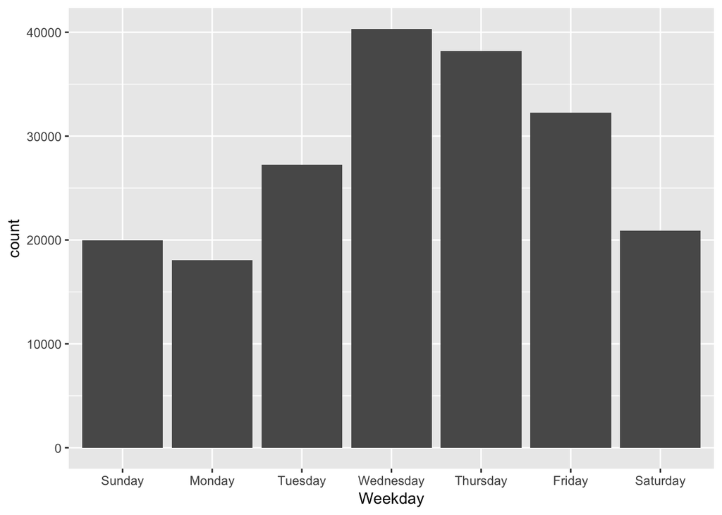

```r
ggplot(citibike, aes(citibike$weekday)) + geom_bar() + labs(x = "Weekday")
```

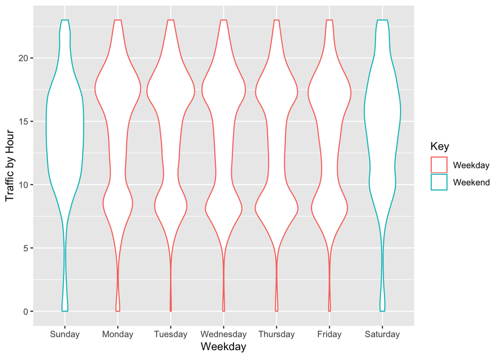

```r
ggplot(citibike, aes(citibike$weekday, citibike$hourtime, colour = citibike$weekend)) + geom_violin() + labs(x = "Weekday", y = "Traffic by Hour", colour = "Key")
```

## Q3

```r
library(plyr)

busystation <- tapply(citibike$start.station.name, citibike$timeOfDay, count)

Morning <- as.data.frame(busystation$Morning)
Morning <- Morning[order(Morning$freq, decreasing = TRUE), ]
head(Morning, 5)
```

```
##                         x freq
## 15        8 Ave & W 31 St  767
## 288       W 41 St & 8 Ave  666
## 280       W 31 St & 7 Ave  446
## 16        8 Ave & W 33 St  361
## 232 Pershing Square South  338
```

```r
Afternoon <- as.data.frame(busystation$Afternoon)
Afternoon <- Afternoon[order(Morning$freq, decreasing = TRUE), ]
head(Afternoon, 5)
```

```
##                  x freq
## 1  1 Ave & E 15 St  135
## 2  1 Ave & E 44 St   58
## 3 10 Ave & W 28 St   77
## 4 11 Ave & W 27 St   91
## 5 11 Ave & W 41 St   97
```

```r
Evening <- as.data.frame(busystation$Evening)
Evening <- Evening[order(Evening$freq, decreasing = TRUE), ]
head(Evening, 5)
```

```
##                            x freq
## 130 E 43 St & Vanderbilt Ave  557
## 195    Lafayette St & E 8 St  542
## 105       E 17 St & Broadway  484
## 272          W 21 St & 6 Ave  441
## 203  Lexington Ave & E 24 St  378
```

```r
afterHours <- as.data.frame(busystation$`After Hours`)
afterHours <- afterHours[order(afterHours$freq, decreasing = TRUE), ]
head(afterHours, 5)
```

```
##                           x freq
## 21  Allen St & E Houston St   29
## 157   Lafayette St & E 8 St   26
## 203     St Marks Pl & 2 Ave   25
## 37       Broadway & E 14 St   24
## 1           1 Ave & E 15 St   23
```

## Q4

I wanted to explore how the age of the user affects the time of day they use the bikes. First, I found it questionable that there were users who were born in 1899 using bikes in 2015. That means they are over 115 years old!

I noticed younger demographics use bikes during morning and afternoon rush hour. I’m assuming these populations use the bikes to complete their work commutes. The older group of 65-90 years old use the bikes consistently throughout the day. Though I find the data a bit questionable for those 90 years and older, it is interesting how none use the bikes before 7 AM.

When splitting the data further by weekday, the oldest generation are extremely volatile in usage patterns, whereas the workforce generations remained relatively consistent.

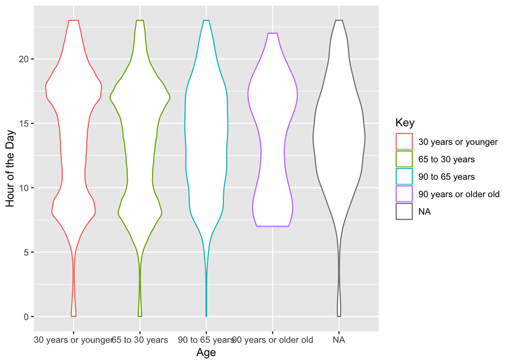

```r
citibike$demographic <- ifelse(citibike$birth.year >= 1900 & citibike$birth.year < 1925, "90 years or older old",ifelse(citibike$birth.year >= 1925 & citibike$birth.year < 1950, "90 to 65 years", ifelse(citibike$birth.year >= 1950 & citibike$birth.year < 1975, "65 to 30 years", "30 years or younger")))

ggplot(citibike, aes(citibike$demographic, citibike$hourtime, colour = citibike$demographic)) + geom_violin() + labs(x = "Age", y = "Hour of the Day", colour = "Key")
```

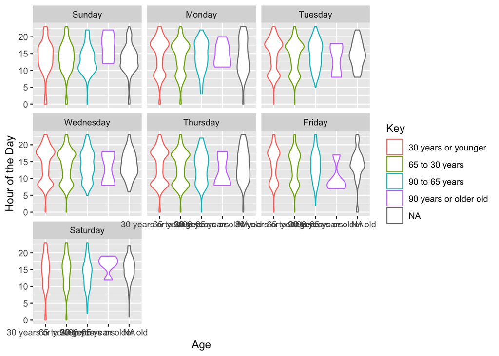

```r
ggplot(citibike, aes(citibike$demographic, citibike$hourtime, colour = citibike$demographic)) + geom_violin() + labs(x = "Age", y = "Hour of the Day", colour = "Key") + facet_wrap(~ citibike$weekday)
```